# R Notebook

```r
library(palmerpenguins)
library(tidyverse)
library(ggplot2)
library(janitor)
library(e1071)
library(gginference)

penguins <- palmerpenguins::penguins
penguins <-  clean_names(penguins)

summary(penguins)
```

```
##       species          island    bill_length_mm  bill_depth_mm
##  Adelie   :152   Biscoe   :168   Min.   :32.10   Min.   :13.10
##  Chinstrap: 68   Dream    :124   1st Qu.:39.23   1st Qu.:15.60
##  Gentoo   :124   Torgersen: 52   Median :44.45   Median :17.30
##                                  Mean   :43.92   Mean   :17.15
##                                  3rd Qu.:48.50   3rd Qu.:18.70
##                                  Max.   :59.60   Max.   :21.50
##                                  NA's   :2       NA's   :2
##  flipper_length_mm  body_mass_g       sex           year
##  Min.   :172.0     Min.   :2700   female:165   Min.   :2007
##  1st Qu.:190.0     1st Qu.:3550   male  :168   1st Qu.:2007
##  Median :197.0     Median :4050   NA's  : 11   Median :2008
##  Mean   :200.9     Mean   :4202                Mean   :2008
##  3rd Qu.:213.0     3rd Qu.:4750                3rd Qu.:2009
##  Max.   :231.0     Max.   :6300                Max.   :2009
##  NA's   :2         NA's   :2
```

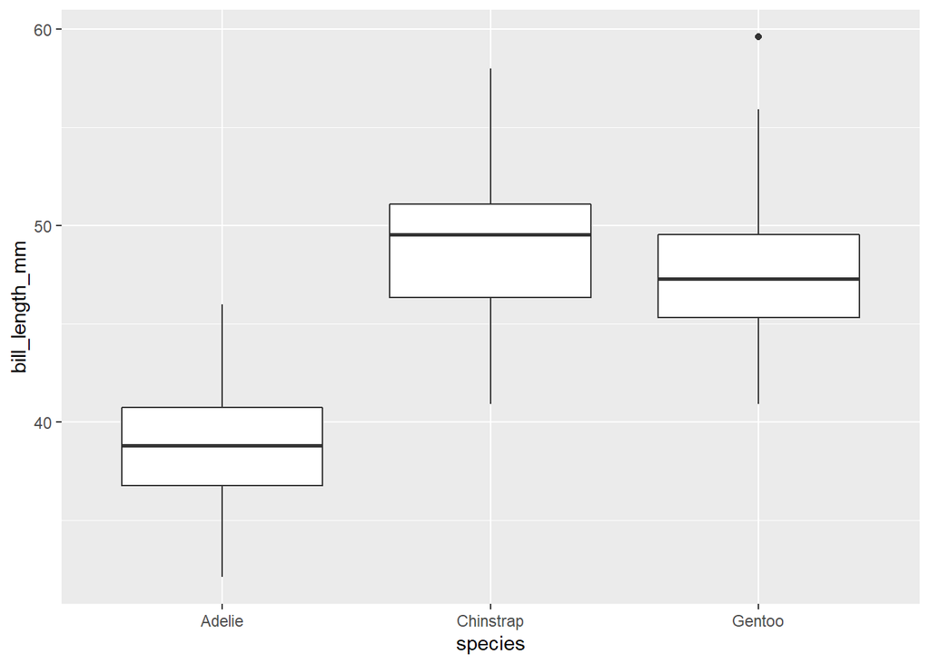

```r
ggplot(penguins, aes(x = species, y = bill_length_mm)) +
    geom_boxplot()
```

the Adelie penguin has the shortest beak length by far, the chinstrap has the longestet beak lenth but there is significant overlap with the gentoo pengiun.

```r
penguins %>%
  filter(!is.na(bill_length_mm)) %>%
  group_by(species) %>%
  summarise(mean(bill_length_mm), median(bill_length_mm), sd(bill_length_mm), skewness(bill_length_mm))
```

| species | mean(bill_length_mm) | median(bill_length_mm) | sd(bill_length_mm) | skewness(bill_length_mm) |
| --- | --- | --- | --- | --- |
| Adelie | 38.79139 | 38.80 | 2.663405 | 0.15847642 |
| Chinstrap | 48.83382 | 49.55 | 3.339256 | -0.08661785 |
| Gentoo | 47.50488 | 47.30 | 3.081857 | 0.63533584 |

the gentoo penguin has data moderatly skewwed to the right, the other two penguines have more ballenced data. the standered deviations show that the data between penguins is simmilarly distributed.

```r
Gentoo <-  penguins %>%
   filter(!is.na(bill_length_mm), species == "Gentoo")
Adelie <-  penguins %>%
   filter(!is.na(bill_length_mm), species == "Adelie")

px = t.test(Gentoo$bill_length_mm, Adelie$bill_length_mm)
px
```

```
##
##  Welch Two Sample t-test
##
## data:  Gentoo$bill_length_mm and Adelie$bill_length_mm
## t = 24.725, df = 242.58, p-value < 2.2e-16
## alternative hypothesis: true difference in means is not equal to 0
## 95 percent confidence interval:
##  8.019303 9.407672
## sample estimates:
## mean of x mean of y
##  47.50488  38.79139
```

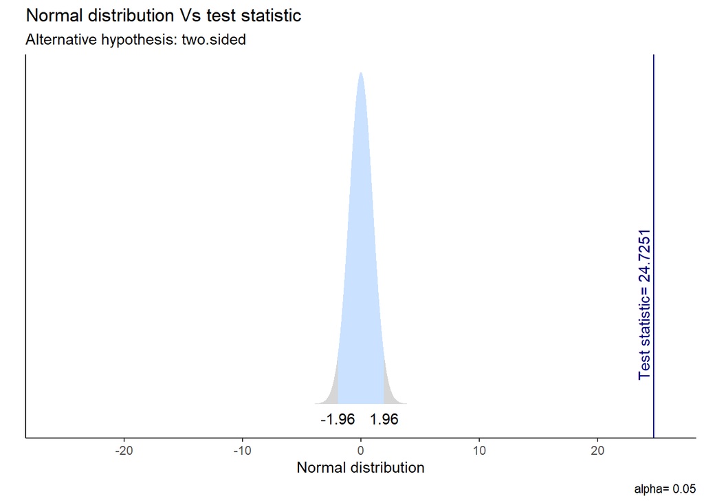

```r
ggttest(px)
```

```r
library(infer)

null_dist <- penguins %>%
  filter(species == c("Gentoo", "Adelie")) %>%
  specify(bill_length_mm ~ species) %>%
  hypothesize(null = "independence") %>%
  generate(reps = 1000, type = "permute") %>%
  calculate(stat = "diff in means", order = c("Gentoo", "Adelie"))

observed_stat <- penguins %>%
  filter(species == c("Gentoo", "Adelie")) %>%
  specify(bill_length_mm ~ species) %>%
  calculate(stat = "diff in means", order = c("Gentoo", "Adelie"))

observed_stat
```

| stat |
| --- |
| 5.579355 |

```r
p_value <- null_dist %>%
  get_p_value(obs_stat = observed_stat, direction = "both")

p_value
```

| p_value |
| --- |
| 0 |

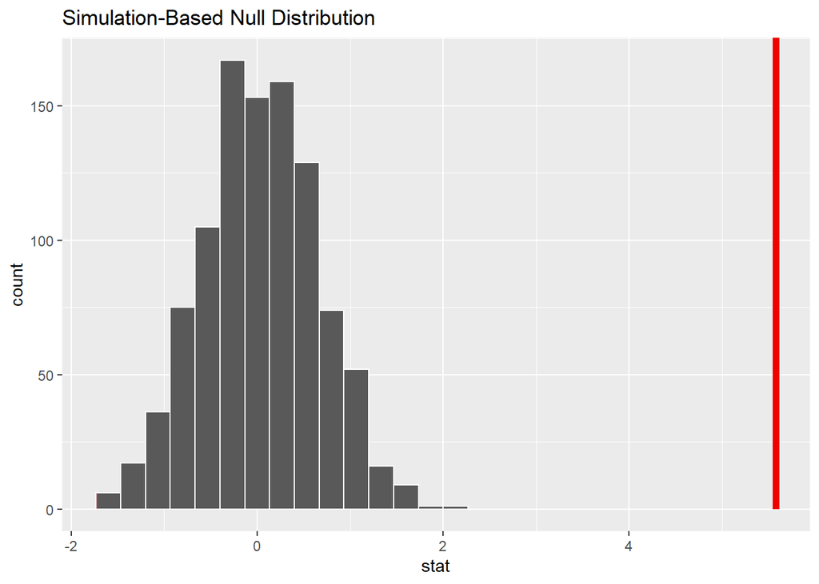

```r
null_dist %>%
  visualise() +
  shade_p_value(obs_stat = observed_stat, direction = "both")
```

H_0 null hipothasis, there is no significant difference between the bill lengths of the Gentoo and the Adelie penguins

H_1 alternative hipothosis, there is a significant difference between the lengths of the bills of the Gentoo and adelie penguin

P value is less than 0.05 and thus we reject the null hypothesis. null hipotheosis is there is no significant difference between the penguins, the alternative apotheosis is that there is a significant difference between the bill lengths of the adelle and Gentoo penguins the T value is greater than 2 so we can infer there is a significant difference between the data.

in the second test, permutation was used to create a simulated null distribution with 1000 reps. this is a process of re-randomization and resampaling different possible combinations of observed data. the p value was calculated to be zero which is likely due to lack of resolution in the infer packages ability. it is in line with the original tests statistic of p-value < 2.2e-16. from this we can reject H_0 and have found enough evidence to suggest that that the bill lenth between the Gentoo and Adslie penguins is significantly different.

below is a correlation matrix of several variables associated with the penguins. in this pearson correlation we can see that flipper lenth and body mass are strongly correlated positively this makes sense as a heavier penguin may require more propulsion in the water thus requiring larger flippers. bill lenth also has a notable positive correlation with flipper lenth and body mass.

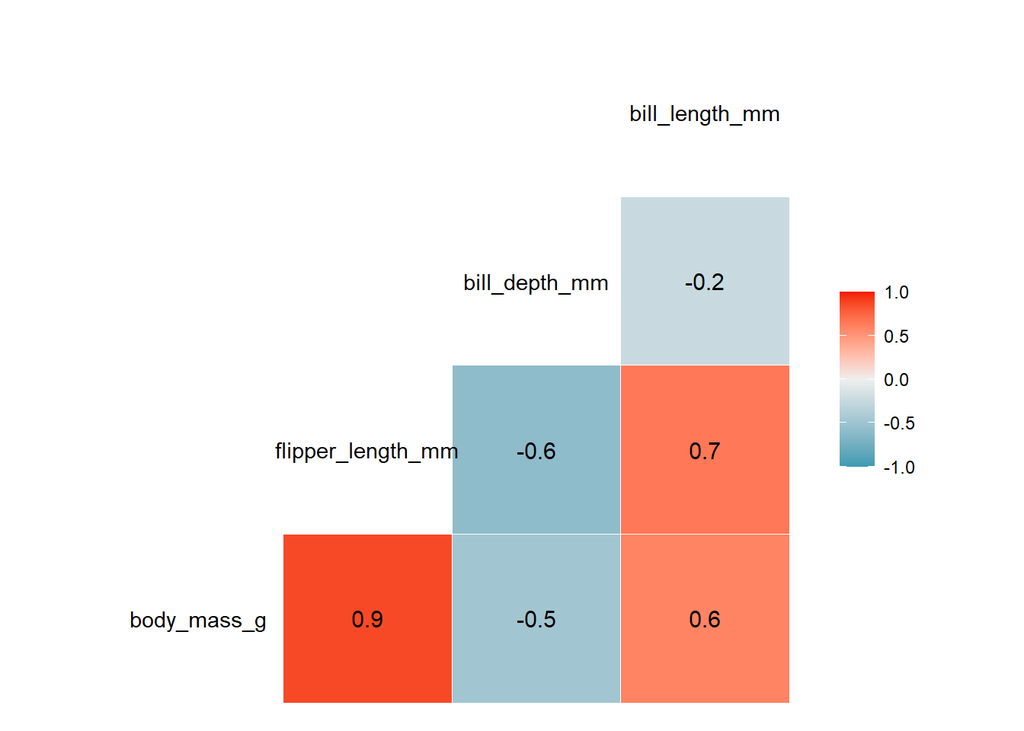

```r
penguins %>%
  select(species, body_mass_g, flipper_length_mm, bill_depth_mm, bill_length_mm) %>%
GGally::ggcorr(label = TRUE, method = c("pairwise", "pearson"))
```